# AID Clase 11

Cecilia Oliva

6 de julio de 2019

# QDA

### Ejemplo 1: Generamos un conjunto de datos simulados.

```r
set.seed(1234)
grupoA_x <- seq(from = -3, to = 4, length.out = 100)-+ rnorm(100, sd = 1)
grupoA_y <- 6 + 0.15 * grupoA_x - 0.3 * grupoA_x^2 + rnorm(100, sd = 1)
grupoA <- data.frame(variable_z = grupoA_x, variable_w = grupoA_y, grupo = "A")

grupoB_x <- rnorm(n = 100, mean = 0.5, sd = 0.8)
grupoB_y <- rnorm(n = 100, mean = 2, sd = 0.9)
grupoB <- data.frame(variable_z = grupoB_x, variable_w = grupoB_y, grupo = "B")

datos <- rbind(grupoA, grupoB)
head(datos)
```

```
##   variable_z variable_w grupo
## 1 -1.7929343  5.1811994     A
## 2 -3.2067222  1.9593531     A
## 3 -3.9430270  0.8103008     A
## 4 -0.4421811  5.3725378     A
## 5 -3.1462964  1.7323026     A
## 6 -3.1525205  2.7125955     A
```

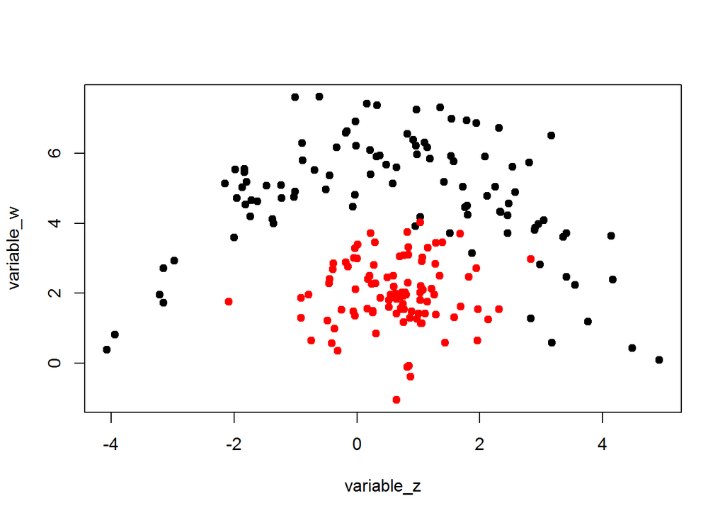

```r
plot(datos[, 1:2], col = datos$grupo, pch = 19)
```

Se aprecia en este gráfico que los datos no son linealmente separables, es probable que QDA ofrezca una mejor alternativa que LDA.

```r
#library(corpcor)
#library(Hotelling)
```

Superponemos los histogramas de las variables z y w por grupo:

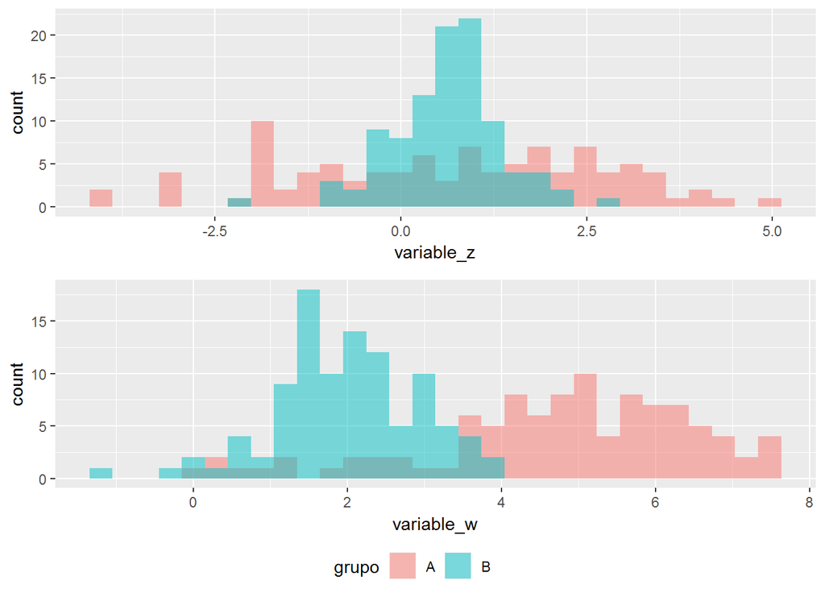

```r
p1 <- ggplot(data = datos, aes(x = variable_z, fill = grupo)) +
  geom_histogram(position = "identity", alpha = 0.5)
p2 <- ggplot(data = datos, aes(x = variable_w, fill = grupo)) +
  geom_histogram(position = "identity", alpha = 0.5)
ggarrange(p1, p2, nrow = 2, common.legend = TRUE, legend = "bottom")
```

Se ve que si bien se superponen tienen distribuciones bien distintas sobre todo para la variable w.

#### Análisis diagnóstico de los supuestos del modelo

Representación mediante histograma de cada variable para cada grupo

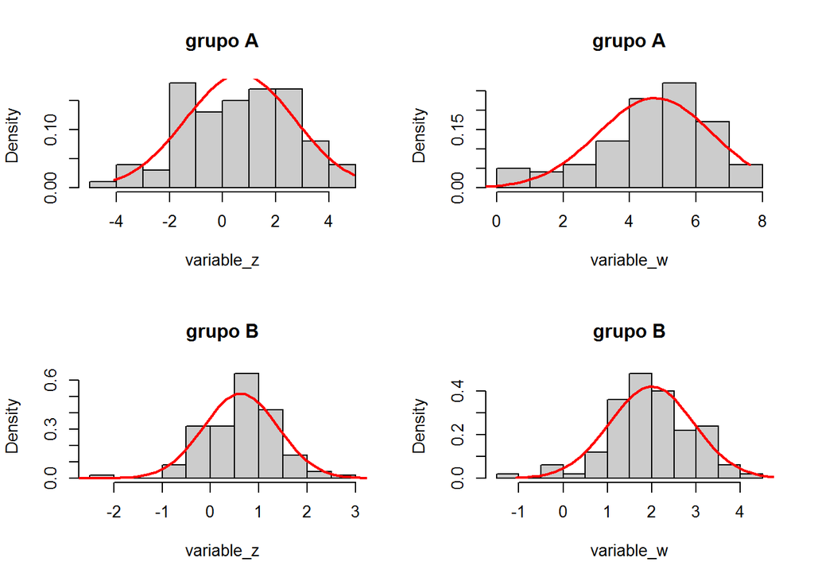

```r
par(mfcol = c(2, 2))
for (k in 1:2) {
  j0 <- names(datos)[k]
  x0 <- seq(min(datos[, k]), max(datos[, k]), le = 50)
  for (i in 1:2) {
    i0 <- levels(datos$grupo)[i]
    x <- datos[datos$grupo == i0, j0]
    hist(x, proba = T, col = grey(0.8), main = paste("grupo", i0),
         xlab = j0)
    lines(x0, dnorm(x0, mean(x), sd(x)), col = "red", lwd = 2)
  }
}
```

Se aprecia que la normalidad ajusta en forma razonable a los histogramas.

QQplot normal por variable para cada grupo:

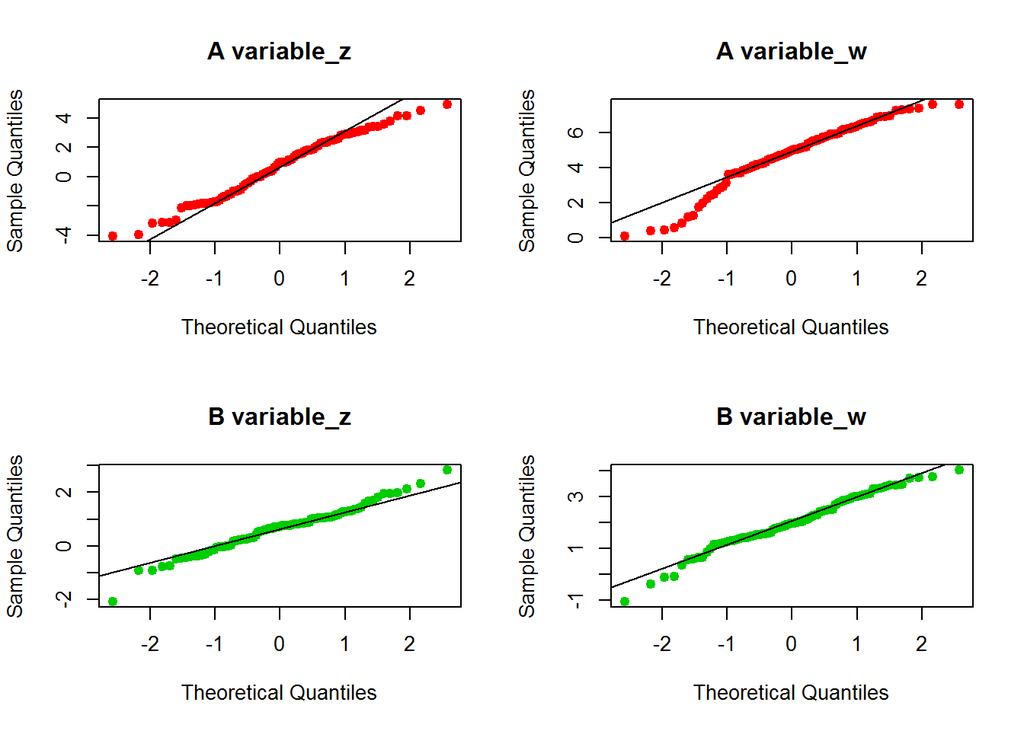

```r
par(mfcol = c(2, 2))
for (k in 1:2) {
  j0 <- names(datos)[k]
  x0 <- seq(min(datos[, k]), max(datos[, k]), le = 50)
  for (i in 1:2) {
    i0 <- levels(datos$grupo)[i]
    x <- datos[datos$grupo == i0, j0]
    qqnorm(x, main = paste(i0, j0), pch = 19, col = i + 1)
    qqline(x)
  }
}
```

```r
par(mfcol = c(1, 1))
```

Contraste de normalidad Shapiro-Wilk para cada variable en cada grupo.

```r
#library(reshape2)
#library(dplyr)
```

```r
datos_tidy <- melt(datos, value.name = "valor")
datos_tidy %>%
  group_by(grupo, variable) %>%
  summarise(p_value_Shapiro.test = round(shapiro.test(valor)$p.value,5))
```

```
## # A tibble: 4 x 3
## # Groups:   grupo [2]
##   grupo variable   p_value_Shapiro.test
##   <fct> <fct>                     <dbl>
## 1 A     variable_z              0.196
## 2 A     variable_w              0.00067
## 3 B     variable_z              0.149
## 4 B     variable_w              0.159
```

La variable w no satisface normalidad univariada en el grupo A.

#### Análisis de normalidad multivariada

```r
#library(mvnormtest)
#library(MASS)
```

```r
mshapiro.test(t(datos[,-3]))
```

```
##
##  Shapiro-Wilk normality test
##
## data:  Z
## W = 0.97519, p-value = 0.001302
```

#### Analizamos igualdad de matrices de varianzas y covarianzas:

```r
#recordar instalar los paquetes si no están instalados aún
#library(biotools)
```

```r
boxM(data = datos[, 1:2], grouping = datos[, 3])
```

```
##
##  Box's M-test for Homogeneity of Covariance Matrices
##
## data:  datos[, 1:2]
## Chi-Sq (approx.) = 115.21, df = 3, p-value < 2.2e-16
```

No se verifica la normalidad multivariada. Si bien QDA tiene cierta robustez frente a la falta de normalidad multivariante, es importante tenerlo en cuenta en la conclusión del análisis.

Tampoco se verifica la igualdad de matrices de varianzas y covarianzas

#### Modelo QDA:

```r
modelo_qda <- qda(grupo ~ variable_z + variable_w, data = datos,CV=TRUE)
#modelo_qda
table(modelo_qda$class,datos$grupo)
```

```
##
##      A  B
##   A 99  6
##   B  1 94
```

```r
mean(modelo_qda$class==datos$grupo) # tasa de buena clasificación del discr. cuadrático
```

```
## [1] 0.965
```

```r
### con muestra de entrenamiento y validación
set.seed(102030)# fijo la semilla para que todos obtengamos los mismos resultados
train=sample(1:200,150)
df_train=data.frame(datos[train,])
df_test=data.frame(datos[-train,])
qda.train=qda(grupo~ variable_z + variable_w, data = df_train)

qda_predTest = predict(qda.train, df_test)
qda_class = predict(qda.train, df_test)$class
table(qda_class, df_test$grupo)
```

```
##
## qda_class  A  B
##         A 26  3
##         B  0 21
```

```r
mean(qda_class== df_test$grupo) # tasa de buena clasificación
```

```
## [1] 0.94
```

#### También podemos aplicar qda robusto (QdaCov, Robust Quadratic Discriminant Analysis)

```r
#library(rrcov)
```

```r
rob.mcd=QdaCov( datos$grupo~., data = datos)
predict(rob.mcd)@classification
```

```
##   [1] A A A A A A A A A A A A A A A A A A A A A A A A A A A A A A A A A A A
##  [36] A A A A A A A A A A A A A A A A A A A A A A A A A A A A A A A A A A A
##  [71] A A A A A A B A A A B A A A A A A A A B A B A A A A A A A B B B B B B
## [106] B B B B B B B B B B B B B B B B B B B B B A B B B B B B B B B A B B B
## [141] B B B B B B B B B B B B B B B B A B B B B B B B B B B B B A B B B B B
## [176] B B B B B B B B B B B B B B B B B B B B B B B B B
## Levels: A B
```

```r
table(predict(rob.mcd)@classification,datos$grupo)
```

```
##
##      A  B
##   A 95  4
##   B  5 96
```

```r
mean(predict(rob.mcd)@classification==datos$grupo) # tasa de buena clasif. ingenua del discr. robusto
```

```
## [1] 0.955
```

Probemos otras alternativas robustas:

```r
rob.sde=QdaCov(datos$grupo~., data = datos, method="sde")
predict(rob.mcd)@classification
```

```
##   [1] A A A A A A A A A A A A A A A A A A A A A A A A A A A A A A A A A A A
##  [36] A A A A A A A A A A A A A A A A A A A A A A A A A A A A A A A A A A A
##  [71] A A A A A A B A A A B A A A A A A A A B A B A A A A A A A B B B B B B
## [106] B B B B B B B B B B B B B B B B B B B B B A B B B B B B B B B A B B B
## [141] B B B B B B B B B B B B B B B B A B B B B B B B B B B B B A B B B B B
## [176] B B B B B B B B B B B B B B B B B B B B B B B B B
## Levels: A B
```

```r
table(predict(rob.sde)@classification,datos$grupo)
```

```
##
##      A  B
##   A 98  4
##   B  2 96
```

```r
mean(predict(rob.sde)@classification==datos$grupo) # tasa de buena clasif. ingenua del discr. robusto
```

```
## [1] 0.97
```

```r
rob.M=QdaCov(datos$grupo~., data = datos, method="M")
predict(rob.mcd)@classification
```

```
##   [1] A A A A A A A A A A A A A A A A A A A A A A A A A A A A A A A A A A A
##  [36] A A A A A A A A A A A A A A A A A A A A A A A A A A A A A A A A A A A
##  [71] A A A A A A B A A A B A A A A A A A A B A B A A A A A A A B B B B B B
## [106] B B B B B B B B B B B B B B B B B B B B B A B B B B B B B B B A B B B
## [141] B B B B B B B B B B B B B B B B A B B B B B B B B B B B B A B B B B B
## [176] B B B B B B B B B B B B B B B B B B B B B B B B B
## Levels: A B
```

```r
table(predict(rob.M)@classification,datos$grupo)
```

```
##
##      A  B
##   A 97  4
##   B  3 96
```

```r
mean(predict(rob.M)@classification==datos$grupo) # tasa de buena clasif. ingenua del discr. robusto
```

```
## [1] 0.965
```

```r
roblog=QdaCov(datos$grupo~., data = datos, method=CovControlOgk())
predict(rob.mcd)@classification
```

```
##   [1] A A A A A A A A A A A A A A A A A A A A A A A A A A A A A A A A A A A
##  [36] A A A A A A A A A A A A A A A A A A A A A A A A A A A A A A A A A A A
##  [71] A A A A A A B A A A B A A A A A A A A B A B A A A A A A A B B B B B B
## [106] B B B B B B B B B B B B B B B B B B B B B A B B B B B B B B B A B B B
## [141] B B B B B B B B B B B B B B B B A B B B B B B B B B B B B A B B B B B
## [176] B B B B B B B B B B B B B B B B B B B B B B B B B
## Levels: A B
```

```r
table(predict(roblog)@classification,datos$grupo)
```

```
##
##      A  B
##   A 99  5
##   B  1 95
```

```r
mean(predict(roblog)@classification==datos$grupo) # tasa de buena clasif. ingenua del discr. robusto
```

```
## [1] 0.97
```

Qué se observa??

### Ejemplo 2

Se observaron dos grupos de salmones de Alaska y Canadá y se quiere determinar el origen de los mismos en función de los datos obtenidos.

```r
#library(ggplot2)
#library(ggpubr)
#library(readxl)
```

```r
salmon <- read_excel("D:/MaestriaDataMining-DeptoCompu/AID/AIDproject/salmon.xlsx")
head(salmon)
```

```
## # A tibble: 6 x 3
##   origen aguadulce   mar
##   <chr>      <dbl> <dbl>
## 1 Alaska       108   368
## 2 Alaska       131   355
## 3 Alaska       105   469
## 4 Alaska        86   506
## 5 Alaska        99   402
## 6 Alaska        87   423
```

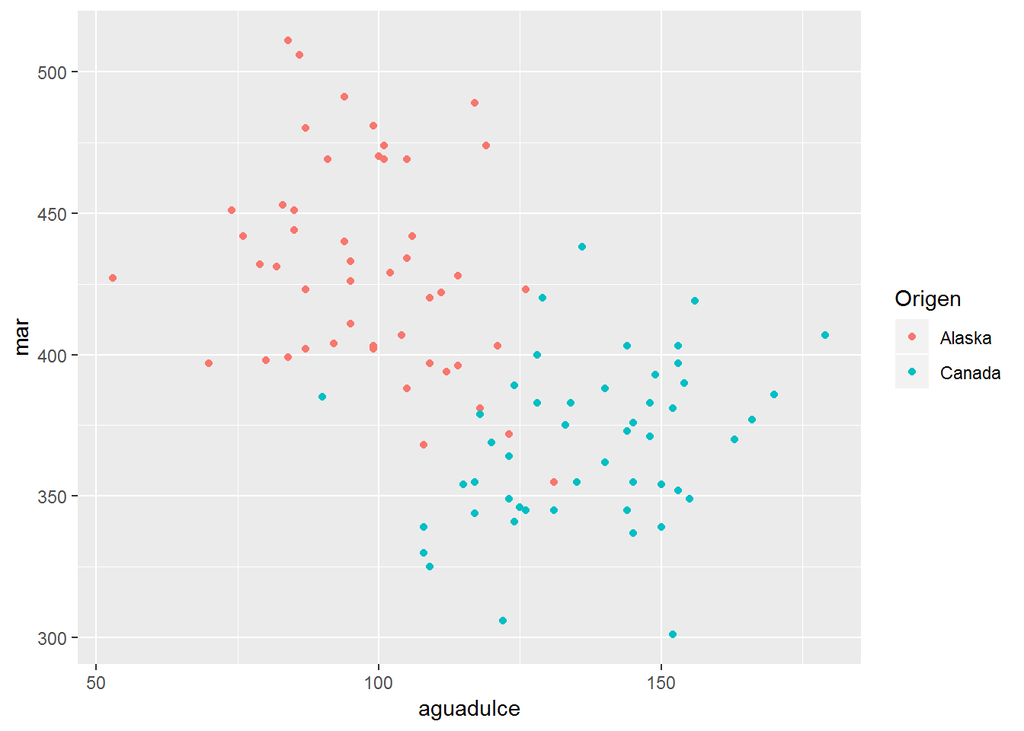

```r
Origen=factor(salmon$origen)
p1=ggplot(aes(x=aguadulce,y=mar,fill=Origen,color=Origen),data=salmon)+
  geom_point(aes(x=aguadulce,y=mar))
p1
```

Observamos las variables candidatas a discriminar.

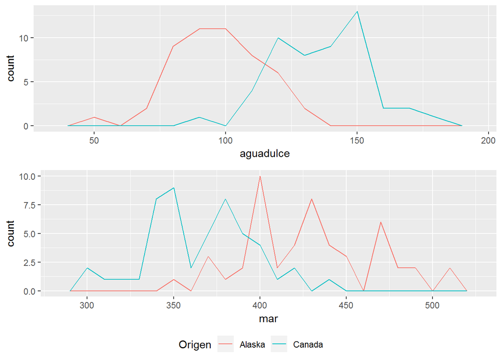

```r
pdul <- ggplot(salmon, aes(aguadulce, colour = Origen)) +
  geom_freqpoly(binwidth = 10)

pmar <-ggplot(salmon, aes(mar, colour = Origen)) +
  geom_freqpoly(binwidth = 10)
ggarrange(pdul, pmar, nrow = 2, common.legend = TRUE, legend = "bottom")
```

#### Veamos si se satisfacen los supuestos de homoscedasticidad y normalidad multivariada.

```r
#library(mvnormtest)
mshapiro.test(t(salmon[,-1]))
```

```
##
##  Shapiro-Wilk normality test
##
## data:  Z
## W = 0.99481, p-value = 0.9699
```

No rechazamos la normalidad multivariada

```r
#library(biotools)
#library(MASS)
```

```r
boxM(data =salmon[,-1], grouping = Origen)
```

```
##
##  Box's M-test for Homogeneity of Covariance Matrices
##
## data:  salmon[, -1]
## Chi-Sq (approx.) = 10.696, df = 3, p-value = 0.01349
```

No se satisface la homoscedasticidad!! Intentamos discriminante cuadrático.

#### Clasificacion ingenua

```r
##clasificacion ingenua
salmon_lda0 <- lda(Origen ~ aguadulce+mar, data = salmon)
salmon_lda0
```

```
## Call:
## lda(Origen ~ aguadulce + mar, data = salmon)
##
## Prior probabilities of groups:
## Alaska Canada
##    0.5    0.5
##
## Group means:
##        aguadulce    mar
## Alaska     98.38 429.66
## Canada    137.46 366.62
##
## Coefficients of linear discriminants:
##                   LD1
## aguadulce  0.04458572
## mar       -0.01803856
```

```r
salmon_qda0 <- qda(Origen ~ aguadulce+mar, data = salmon)
salmon_qda0
```

```
## Call:
## qda(Origen ~ aguadulce + mar, data = salmon)
##
## Prior probabilities of groups:
## Alaska Canada
##    0.5    0.5
##
## Group means:
##        aguadulce    mar
## Alaska     98.38 429.66
## Canada    137.46 366.62
```

```r
##LDA

prediccionesLda <- predict(object = salmon_lda0, newdata = salmon[,-1])
table(salmon$origen, prediccionesLda$class, dnn = c("Origen real", "Origen predicho"))
```

```
##            Origen predicho
## Origen real Alaska Canada
##      Alaska     44      6
##      Canada      1     49
```

```r
error_ingenuo_lda<- mean(salmon$origen != prediccionesLda$class) * 100
error_ingenuo_lda#7%
```

```
## [1] 7
```

```r
##QDA

prediccionesQda <- predict(object = salmon_qda0, newdata = salmon[,-1])
table(salmon$origen, prediccionesQda$class, dnn = c("Origen real", "Origen predicho"))
```

```
##            Origen predicho
## Origen real Alaska Canada
##      Alaska     45      5
##      Canada      2     48
```

```r
error_ingenuo_qda<- mean(salmon$origen != prediccionesQda$class) * 100
error_ingenuo_qda#7%
```

```
## [1] 7
```

#### Clasificación cv-loo

```r
## clasificación cv-loo
salmon_lda <- lda(Origen ~ aguadulce+mar, data = salmon,CV=TRUE)
#salmon_lda
salmon_qda <- qda(Origen ~ aguadulce+mar, data = salmon,CV=TRUE)
#salmon_qda


##LDA

table(salmon_lda$class,Origen)
```

```
##         Origen
##          Alaska Canada
##   Alaska     44      1
##   Canada      6     49
```

```r
TasaBuenaclasif_lda<-mean(salmon_lda$class==Origen)#0.93 # tasa de buena clasificación del discr lineal
TasaBuenaclasif_lda
```

```
## [1] 0.93
```

```r
error_cvloo_lda<-mean(salmon_lda$class!=Origen)#0.07 # tasa de error
error_cvloo_lda
```

```
## [1] 0.07
```

```r
##QDA

table(salmon_qda$class,Origen)
```

```
##         Origen
##          Alaska Canada
##   Alaska     45      3
##   Canada      5     47
```

```r
TasaBuenaclasif_qda<-mean(salmon_qda$class==Origen)# tasa de buena clasificación del discr cuadrático
TasaBuenaclasif_qda
```

```
## [1] 0.92
```

```r
error_cvloo_qda<-mean(salmon_qda$class!=Origen)# tasa de error
error_cvloo_qda
```

```
## [1] 0.08
```

#### Clasificación con entrenamiento y validación

```r
## clasificación con entrenamiento y validación
set.seed(2019)
entrenamiento<-sample(1:100,70)
validacion<-c(1:100)[-entrenamiento]
salmon_lda1 <- lda(origen ~ aguadulce+mar, data = salmon[entrenamiento,])
salmon_lda1
```

```
## Call:
## lda(origen ~ aguadulce + mar, data = salmon[entrenamiento, ])
##
## Prior probabilities of groups:
##    Alaska    Canada
## 0.5142857 0.4857143
##
## Group means:
##        aguadulce      mar
## Alaska  97.80556 429.2222
## Canada 136.97059 367.2059
##
## Coefficients of linear discriminants:
##                   LD1
## aguadulce  0.04468636
## mar       -0.01851034
```

```r
salmon_qda1 <- qda(origen ~ aguadulce+mar, data = salmon[entrenamiento,])
salmon_qda1
```

```
## Call:
## qda(origen ~ aguadulce + mar, data = salmon[entrenamiento, ])
##
## Prior probabilities of groups:
##    Alaska    Canada
## 0.5142857 0.4857143
##
## Group means:
##        aguadulce      mar
## Alaska  97.80556 429.2222
## Canada 136.97059 367.2059
```

```r
##LDA

prediccionesLda_2 <- predict(object = salmon_lda1, newdata = salmon[validacion,-1])
table(salmon$origen[validacion], prediccionesLda_2$class, dnn = c("Origen real", "Origen predicho"))
```

```
##            Origen predicho
## Origen real Alaska Canada
##      Alaska     12      2
##      Canada      0     16
```

```r
error_test_lda<- mean(salmon$origen[validacion] != prediccionesLda_2$class) * 100
error_test_lda#6.666667%
```

```
## [1] 6.666667
```

```r
##QDA

prediccionesQda_2<- predict(object = salmon_qda1, newdata = salmon[validacion,-1])
table(salmon$origen[validacion], prediccionesQda_2$class, dnn = c("Origen real", "Origen predicho"))
```

```
##            Origen predicho
## Origen real Alaska Canada
##      Alaska     13      1
##      Canada      1     15
```

```r
error_test_qda<- mean(salmon$origen[validacion] != prediccionesQda_2$class) * 100
error_test_qda#6.666667%
```

```
## [1] 6.666667
```

Es razonable??

#### Gráficos de las particiones según QDA y LDA

```r
#library(klaR)
```

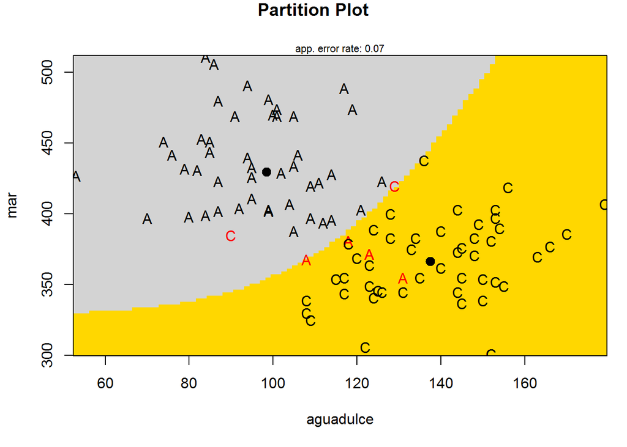

```r
Origen=factor(salmon$origen)
partimat(Origen ~ mar+aguadulce, data = salmon, method = "qda",
         imageplot = TRUE,col.mean=1,image.colors = c("lightgrey","gold"))
```

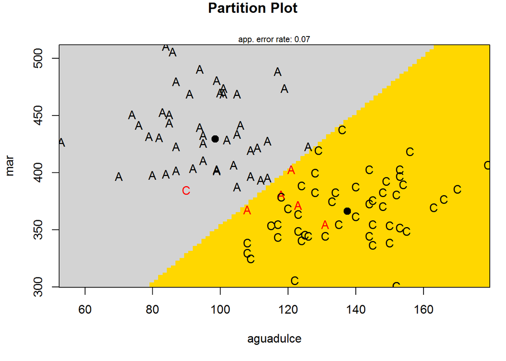

```r
partimat(Origen ~ mar+aguadulce, data = salmon, method = "lda", col.mean=1,
         imageplot = TRUE,image.colors = c("lightgrey","gold"))
```